# biota adjustments

#### Part 2

Here is a plot of mercury data at Forth_LowerForthEstuary_fi01 with the SEPA data from 2008 and before in red. The SEPA data from 1999 and 2001 are deleted because it is unclear whether any differences over time are environmental or analytical.

```r
wk_station <- "Forth_LowerForthEstuary_fi01"
```

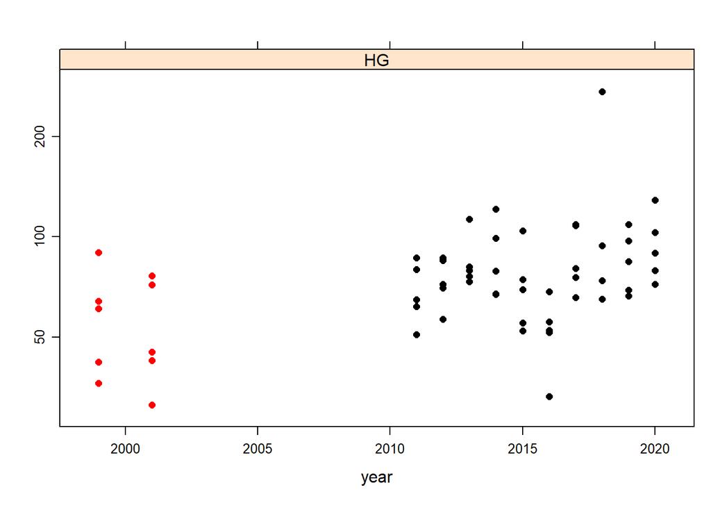

```r
biota_data$data <- mutate(
  biota_data$data,
  .station = station_name %in% wk_station,
  .id = .station & determinand %in% "HG",
  .drop = .id & year <= 2008
)


wk_data <- biota_data$data %>%
  mutate(.matrix = if_else(determinand %in% c("HG", "AS"), "MU", "LI")) %>%
  filter(.id & matrix == .matrix) %>%
  mutate(value = convert.units(value, unit, "ug/kg"))

wk_dry <- biota_data$data %>%
  filter(.station & determinand %in% "DRYWT%") %>%
  select(sub.sample, matrix, value) %>%
  rename(dry_weight = value)

wk_lipid <- biota_data$data %>%
  filter(.station & determinand %in% "LIPIDWT%") %>%
  select(sub.sample, matrix, value) %>%
  rename(lipid_weight = value)

wk_data <- left_join(wk_data, wk_dry, by = c("sub.sample", "matrix"))
wk_data <- left_join(wk_data, wk_lipid, by = c("sub.sample", "matrix"))

wk_n <- nrow(wk_data)

wk_data <- mutate(
  wk_data,
  value = convert.basis(
    value, basis, rep("W", wk_n),
    dry_weight, rep("", wk_n),
    lipid_weight, rep("", wk_n)
  )
)

lattice::xyplot(
  value ~ year | determinand, data = wk_data,
  ylab = "",
  scales = list(y = list(log = TRUE, equispaced.log = FALSE, relation = "free"), alternating = FALSE),
  panel = function(x, y, subscripts) {
    data <- wk_data[subscripts, ]
    .id <- data$.drop
    lattice::lpoints(x[!.id], y[!.id], col = "black", pch = 16)
    lattice::lpoints(x[.id], y[.id], col = "red", pch = 16)
  }
)
```

```r
biota_data$data <- biota_data$data %>%
  filter(!.drop) %>%
  mutate(
    .station = NULL,
    .id = NULL,
    .drop = NULL
  )

rm(wk_dry, wk_lipid, wk_n, wk_data, wk_station)
```

### UK: EA units

There are mercury unit errors at five EA stations in 2006 (Anglia_ThamesMid_fi01, Anglia_ThamesLw_fi02, Anglia_Medway_fi02, HumWash_HumberLow_fi01 and IrishSea_Ribble_fi01.) Here is a plot of the timeseries of mercury concentrations in muscle at these stations with the 2006 data in red. All concentrations are in ug/kg ww. As it turns out, this is a legacy issue, since fish are no longer monitored at these stations.

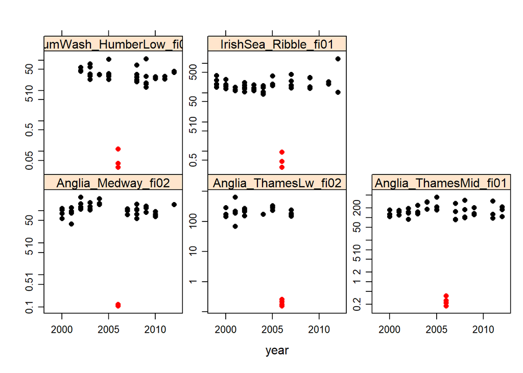

```r
biota_data$data <- mutate(
  biota_data$data,
  .id = country %in% "United Kingdom" &
    station_name %in% c(
      "Anglia_ThamesMid_fi01", "Anglia_ThamesLw_fi02", "Anglia_Medway_fi02",
      "HumWash_HumberLow_fi01", "IrishSea_Ribble_fi01") &
    matrix %in% "MU" &
    determinand %in% "HG",
  .change = .id & year == 2006
)

wk_data <- biota_data$data %>%
  filter(.id) %>%
  mutate(value = convert.units(value, unit, "ug/kg"))

if (!all(wk_data$basis %in% "W"))
  warning("need to convert basis")

if (!all(wk_data$unit %in% "ug/kg"))
  warning("need to investigate units")

if (any(wk_data$year >= 2015))
  warning("new data submitted - need to investigate")

lattice::xyplot(
  value ~ year | station_name, data = wk_data,
  ylab = "",
  scales = list(y = list(log = TRUE, equispaced.log = FALSE, relation = "free"), alternating = FALSE),
  panel = function(x, y, subscripts) {
    data <- wk_data[subscripts, ]
    .id <- data$.change
    lattice::lpoints(x[!.id], y[!.id], col = "black", pch = 16)
    lattice::lpoints(x[.id], y[.id], col = "red", pch = 16)
  }
)
```

The data are corrected by changing the units to mg/kg in the data file. Here is a plot of the corrected data.

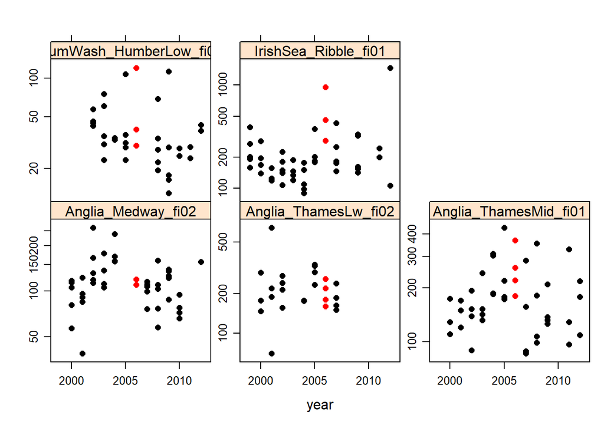

```r
biota_data$data <- mutate(
  biota_data$data,
  unit = if_else(.change, "mg/kg", unit)
)

wk_data <- biota_data$data %>%
  filter(.id) %>%
  mutate(value = convert.units(value, unit, "ug/kg"))

lattice::xyplot(
  value ~ year | station_name, data = wk_data,
  ylab = "",
  scales = list(y = list(log = TRUE, equispaced.log = FALSE, relation = "free"), alternating = FALSE),
  panel = function(x, y, subscripts) {
    data <- wk_data[subscripts, ]
    .id <- data$.change
    lattice::lpoints(x[!.id], y[!.id], col = "black", pch = 16)
    lattice::lpoints(x[.id], y[.id], col = "red", pch = 16)
  }
)
```

```r
biota_data$data <- mutate(
  biota_data$data,
  .id = NULL,
  .change = NULL
)
```

### AMAP preparation

The following changes are required to reliably merge the ICES data with the AMAP mercury data. These need to be built into the core routines. (Some of them are already there, but are only implemented after the merge takes place, which is too late!)

#### Data outside OSPAR area

Drop data from outside the OSPAR area

```r
biota_data$data <- filter(
  biota_data$data,
  !is.na(OSPARregion)
)
```

#### PURPM and Governance

Stations submitted for AMAP (but not OSPAR) will not be identifed as valid stations by code unless OSPAR is added to the programGovernance field and PURPM is set to T

```r
biota_data$stations <- mutate(
  biota_data$stations,

  .id = strsplit(programGovernance, "~") %>%
      sapply(function(x) ("AMAP" %in% x) & !("OSPAR" %in% x)),
  programGovernance = if_else(
    .id,
    paste0(programGovernance, "~OSPAR"),
    programGovernance
  ),

  PURPM = if_else(.id & is.na(PURPM), "T", PURPM),

  .T = strsplit(PURPM, "~") %>% sapply(function(x) "T" %in% x),
  PURPM = if_else(.id & !.T, paste0(PURPM, "~T"), PURPM),

  .id = NULL,
  .T = NULL
)
```

#### Mammal sub-groups

Add a column to allow the creation of different mammal groups based on age (size) and sex.

```r
biota_data$data$AMAP_group <- "Not_applicable"
```

### Faroes: data corrections

These data are scheduled for resubmission so the changes below are not described in detail.

#### Delete rlabo HFSF

Data from reporting lab HFSF is deleted as it is legacy data.

```r
biota_data$data <- filter(
  biota_data$data,
  !(country %in% "Denmark" &
      region %in% "Greenland-Scotland ridge" &
      rlabo %in% "HFSF"
  )
)
```

#### Pilot whale stations

Here is a table of pilot whale measurements by submitted station and by station name (if recognised by the station dictionary).

```r
wk_data <- filter(
  biota_data$data,
  country %in% "Denmark",
  region %in% "Greenland-Scotland ridge",
  species %in% "Globicephala melas"
)

with(wk_data, table(submitted.station)) %>%
  print(zero.print = ".")
```

```
submitted.station
 Føroyskar hvalvágir  Føroyskar Hvalvágir         Fuglafjørður              Hvalvík
                 418                  303                   76                   50
          Hvannasund               Leynar             Miðvágur           Sandavágur
                 259                   36                   70                   76
            Tórshavn Tórshavn - Sandagerð            Vestmanna
                  40                   41                  154
```

```r
with(wk_data, table(station_name)) %>%
  print(zero.print = ".")
```

```
station_name
        Fuglafjørður              Hvalvík           Hvannasund               Leynar
                  76                   50                  259                   36
            Miðvágur           Sandavágur Tórshavn - Sandagerð            Vestmanna
                  70                   76                   41                  154
```

```r
wk_station <- biota_data$stations %>%
  filter(code == "902") %>%
  pull(station)
```

For assessment purposes these data are all taken to come from a single station covering the waters around Faroes: specifically Føroyskar hvalvágir. Here is a summary of the number of measurements by year.

```r
biota_data$data <- mutate(
  biota_data$data,
  .id = country %in% "Denmark" &
    region %in% "Greenland-Scotland ridge" &
    species %in% "Globicephala melas",
  station_name = if_else(.id, wk_station, station_name),
  station_code = if_else(.id, "902", station_code),
)

biota_data$data %>%
  filter(.id) %>%
  with(table(station_name, year))
```

```
                     year
station_name          2001 2002 2003 2004 2007 2009 2010 2011 2012 2013 2015 2016
  Føroyskar hvalvágir  170  147   47   56   93  126   99  142  161  152  171  159
```

```r
biota_data$data$.id <- NULL
rm(wk_station)
```

#### Guillemot stations

Here is a table of black guillemot measurements by submitted station and station name (if recognised by the station dictionary).

```r
wk_data <- filter(
  biota_data$data,
  country %in% "Denmark",
  region %in% "Greenland-Scotland ridge",
  species %in% "Cepphus grylle"
)

with(wk_data, table(submitted.station, station_name, useNA = "ifany")) %>%
  print(zero.print = ".")
```

```
                 station_name
submitted.station Koltur Skúvoy Sveipur Tindhólmur <NA>
       Koltur         92      .       .          .    .
       KOLTUR        230      .       .          .    .
       Skuvoy          .      .       .          .   24
       Skúvoy          .    107       .          .    .
       SKÚVOY          .    154       .          .    .
       Sveipur         .      .     148          .    .
       Tindhólmur      .      .       .        128    .
```

```r
wk_station <- biota_data$stations %>%
  filter(code == "916") %>%
  pull(station)
```

Somehow everything seems to have matched up, apart for data submitted with station Skuvoy, which needs to be changed to Skúvoy.

```r
biota_data$data <- mutate(
  biota_data$data,
  .id = country %in% "Denmark" &
    region %in% "Greenland-Scotland ridge" &
    species %in% "Cepphus grylle" &
    submitted.station %in% "Skuvoy",
  station_name = if_else(.id, wk_station, station_name),
  station_code = if_else(.id, "916", station_code),
  .id = NULL
)

biota_data$data %>%
  filter(
    country %in% "Denmark",
    region %in% "Greenland-Scotland ridge",
    species %in% "Cepphus grylle"
  ) %>%
  with(table(station_name, year))
```

```
            year
station_name 1999 2000 2001 2002 2004 2006 2007 2008 2009 2010 2011 2012 2013 2014 2015 2016
  Koltur       30   30   30   30   10   30    0   40    0   40    0    0   28   24    0   30
  Skúvoy       24   27   30   21    7   30    0   36    0   40    0   30    0   40    0    0
  Sveipur       0    0    0   20    0    0   16    0   24    0   24    0   32    0   32    0
  Tindhólmur    0    0    0    0    0    0   14    0   27    0   27    0   32    0   28    0
```

```r
rm(wk_station)
```

Note that data for cod and northern fulmar are correctly matched up.

```r
wk_data <- filter(
  biota_data$data,
  country %in% "Denmark",
  region %in% "Greenland-Scotland ridge",
  species %in% c("Gadus morhua", "Fulmarus glacialis")
)

with(wk_data, table(species, year)) %>%
  print(zero.print = ".")
```

```
                    year
species              2003 2006 2008 2009 2010 2011 2012 2013 2014 2015 2016
  Fulmarus glacialis    .    .    .    .    .    .    .    .    .    .   40
  Gadus morhua         45   45  102   85   74   72   70   70   70   78   82
```

```r
with(wk_data, table(submitted.station, station_name, useNA = "ifany")) %>%
  print(zero.print = ".")
```

```
                 station_name
submitted.station Mýlingsgrunnur Vestmanna
   Mýlingsgrunnur            793         .
   Vestmanna                   .        40
```

### Faroes: extra

The following sections attempt to make the treatment of data from the ICES extraction consistent with the treatment of mercury data in the AMAP mercury assessment (Birgitta). Not many changes are made here, but is good to retain these reflections for when the data have been resubmitted.

This is the sort of thing that I have to do when there are data in both the ICES extraction and the external data. The code below was written for the full data set (i.e. other metals and organics), but illustrates the lengths involved. It is not really needed for this mercury example.

```r
# read in AMAP mercury data - note this has been filtered from the original file where more information can be found.

wk_AMAP <-
  file.path("data", "example_external_data", "AMAP_MIME_data.xlsx") %>%
  readxl::read_excel(
    col_types = rep(
      c("guess", "skip", "guess", "skip", "guess", "skip"),
      times = c(7, 3, 1, 6, 1, 1)
    )
  ) %>%
  filter(
    country %in% "Denmark",
    species %in% c(
      "Cepphus grylle", "Fulmarus glacialis", "Gadus morhua", "Globicephala melas"
    )
  )
```

#### Remove Hg data

Remove the mercury data in the ICES extraction for those stations and years (2017 and earlier) that are also in the AMAP data set. This is because of the better data quality control applied to the AMAP data set before the AMAP mercury assessment.

As it turns out, there aren’t any mercury data in the ICES extraction after 2017. In practice, this means that mercury assessments are based on the AMAP data set and the assessment of all other contaminants is based on the ICES extraction.

```r
# check station_names and species in both the AMAP and ICES data sets are identical (i.e. no extra time series lurking about that haven't been accounted for)

biota_data$data <- mutate(
  biota_data$data,
  .id = country %in% "Denmark" &
    region %in% "Greenland-Scotland ridge" &
    species %in% c(
      "Cepphus grylle", "Fulmarus glacialis", "Gadus morhua", "Globicephala melas"
    )
)

wk_data <- biota_data$data %>%
  filter(.id) %>%
  select(station_name, species) %>%
  distinct() %>%
  arrange(station_name)

wk_AMAP2 <- wk_AMAP %>%
  select(station_name, species) %>%
  distinct() %>%
  arrange(station_name)

if (!(identical(wk_data$station_name, wk_AMAP2$station_name) &
      identical(wk_data$species, wk_AMAP2$species))
) warning("time series inconsistencies - look at what has changed")

biota_data$data <- biota_data$data %>%
  mutate(.id = .id & determinand %in% "HG" & year <= 2017) %>%
  filter(!.id) %>%
  mutate(.id = NULL)

rm(wk_AMAP2)
```

#### Cod lengths

In the AMAP mercury assessment, cod were grouped into ‘medium’ and ‘undefined’ lengths and each group was assessed separately. The medium lengths were from 50 to 60 cm (see below) and the undefined lengths ranged from 23 cm to 109 cm with a median of 61 cm.

In the MIME assessment, only the medium group is assessed, since the undefined group does not make sense biologically.

```r
wk_AMAP %>%
  filter(
    species %in% "Gadus morhua",
    determinand %in% "LNMEA"
  ) %>%
  pull(value) %>%
  summary()
```

```
   Min. 1st Qu.  Median    Mean 3rd Qu.    Max.
   50.0    52.0    54.0    54.6    57.0    60.0
```

```r
biota_data$data %>%
  filter(
    species %in% "Gadus morhua",
    station_code %in% "911",
    determinand %in% "LNMEA"
  ) %>%
  pull(value) %>%
  summary()
```

```
   Min. 1st Qu.  Median    Mean 3rd Qu.    Max.
  41.00   47.00   50.00   49.97   52.50   61.00
```

#### Fulmar age

The fulmar mercury data were identified as pullus by Birgitta, but there are no age data in either the AMAP data or the ICES extraction to confirm this (nor is there suitable classification information in any other record that I can see)

#### Pilot whale: mammal group

In the AMAP mercury assessment, the data were grouped into adults or juvenile males:

- adults: females $\ge$ 375cm or males $\ge$ 495cm
- juvenile males: males with lengths between 320 and 494cm

(I have a note that 325 or 500 might be more sensible values for the males - don’t know why, but might be worth re-investigating the length distributions.)

The same groupings are applied for the assessment of the other contaminants in the ICES extraction

```r
# This shows the minimum length in each group by sex

# wk_AMAP %>%
#   filter(
#     species %in% "Globicephala melas",
#     determinand %in% "LNMEA"
#   ) %>%
#   with(tapply(value, list(sex, AMAP_group), min))


wk_length <- biota_data$data %>%
  filter(determinand %in% "LNMEA") %>%
  select(sub.sample, value) %>%
  rename(.length = value) %>%
  distinct()

if (anyDuplicated(wk_length$sub.sample))
  stop("duplicate sub samples - investigate")

biota_data$data <-
  left_join(biota_data$data, wk_length, by = "sub.sample") %>%
  mutate(
    .id = station_code %in% "902" & species %in% "Globicephala melas",
    AMAP_group = case_when(
      .id & sex %in% "F" & .length >= 375 ~ "Adult",
      .id & sex %in% "M" & .length >= 495 ~ "Adult",
      .id & sex %in% "M" & .length >= 320 ~ "Juvenile_male",
      .id                                 ~ NA_character_,
      TRUE                                ~ AMAP_group
    ),
    .id = NULL,
    .length = NULL
  ) %>%
  drop_na(AMAP_group)
```

#### Guillemot: juveniles

The guillemot time series in the mercury AMAP data set are grouped as juvenile and undefined:

- Tindhólmur: all juveniles
- Sveipur: most juvenile and a few undefined (which were discarded)
- Koltur: all undefined
- Skúvoy: all undefined

However, there are no supporting data to show how these selections were made. Have used all available data in the ICES extraction.

### Greenland

Data from Greenland should theoretically be the same in both the ICES extraction and the AMAP external data file. However, the data submitted to ICES are not correct. So drop all Greenland data from the ICES extraction.

```r
biota_data$data <- biota_data$data %>%
  filter(! ices_ecoregion %in% "Greenland Sea") %>%
  mutate(.id = NULL)
```

### Non-marine species

Drop Arctic char, Arctic fox, northern pike, brown trout, rock ptarmigan because they are not marine species. These could be omitted in the species information file, but it is more explicit to do it here, and there is some ambiguity about whether e.g. char should be included or not.

```r
biota_data$data <- filter(
  biota_data$data,
  !species %in% c(
    "Salvelinus alpinus",
    "Vulpes lagopus",
    "Esox lucius",
    "Salmo trutta",
    "Lagopus muta"
  )
)
```

### AMAP external data

#### Data input

Merge data file with external AMAP file used for AMAP mercury assessment. Note that some pre-processing of the AMAP data has already been done (elsewhere) to e.g. remove stations not in the OSPAR area. A different data set was used in the last AMAP assessment.

```r
# pre-processing to remove Region 0 data and weird groups
# this was done in 2021 assessment and the data files have just been copied across

# source("OSPAR 2021 AMAP preparation.r")

# read in non-ICES data and stations

biota_data <- add_non_ICES_data(
  biota_data, "AMAP_MIME_data.xlsx", "AMAP_MIME_stations.xlsx",
  keep = "all",
  path = file.path("data", "example_external_data")
)
```

#### Svalbard edits

Remove polar bear data for years up to 1994 inclusive (Simon 30/12/2021).

```r
biota_data$data <- biota_data$data %>%
  mutate(
    .id = species %in% "Ursus maritimus" &
      country %in% "Norway" &
      station_code %in% "A47001" &
      year <= 1994
  ) %>%
  filter(!.id) %>%
  mutate(.id = NULL)
```